# MECH481A6: Engineering Data Analysis in R

Chapter 5 Homework: Exploring Univariate Data

Student Name

07 October, 2025

# Grading

We will grade the **knitted** PDF or HTML document from within your private GitHub repository. Remember to make regular, small commits (e.g., at least one commit per question) to save your work. We will grade the latest knit, as long as it occurs *before* the start of the class in which we advance to the next chapter. As always, reach out with questions via GitHub Issues or during office hours.

# Data

You are probably sick of seeing the ozone data, but there’s still more to do with the file. Ozone concentration measurement is considered univariate, thus we can use basic exploratory data analysis approaches to examine the data.

# Preparation

Load the necessary R packages into your R session.

Recreate the pipe of `dplyr` functions that you used to import the data, select and rename the variables listed below, drop missing observations, and assign the output with a good name.

- `sample_measurement` renamed as `ozone_ppm` (ozone measurement in ppm)
- `datetime` (date in YYYY-MM-DD format and time of measurement in HH:MM:SS)

```
## # A tibble: 16,914 × 3
##    datetime            ozone_ppm ozone_ugm3
##    <dttm>                  <dbl>      <dbl>
##  1 2019-01-01 07:00:00     0.017       36.4
##  2 2019-01-01 08:00:00     0.017       36.4
##  3 2019-01-01 09:00:00     0.017       36.4
##  4 2019-01-01 10:00:00     0.017       36.4
##  5 2019-01-01 11:00:00     0.015       32.1
##  6 2019-01-01 12:00:00     0.017       36.4
##  7 2019-01-01 13:00:00     0.028       60.0
##  8 2019-01-01 14:00:00     0.03        64.2
##  9 2019-01-01 15:00:00     0.036       77.1
## 10 2019-01-01 16:00:00     0.036       77.1
## # ℹ 16,904 more rows
```

Check that the data imported correctly.

```
##  site_number           latitude       longitude        date_local
##  Length:16914       Min.   :40.58   Min.   :-105.1   Min.   :2019-01-01
##  Class :character   1st Qu.:40.58   1st Qu.:-105.1   1st Qu.:2019-03-30
##  Mode  :character   Median :40.59   Median :-105.1   Median :2019-06-27
##                     Mean   :40.59   Mean   :-105.1   Mean   :2019-06-30
##                     3rd Qu.:40.59   3rd Qu.:-105.1   3rd Qu.:2019-10-03
##                     Max.   :40.59   Max.   :-105.1   Max.   :2019-12-31
##
##    time_local                 datetime                   sample_measurement
##  Min.   :00:00:00.000000   Min.   :2019-01-01 07:00:00   Min.   :0.00000
##  1st Qu.:05:00:00.000000   1st Qu.:2019-03-30 20:15:00   1st Qu.:0.02300
##  Median :12:00:00.000000   Median :2019-06-27 11:30:00   Median :0.03300
##  Mean   :11:30:52.997517   Mean   :2019-07-01 06:01:45   Mean   :0.03305
##  3rd Qu.:18:00:00.000000   3rd Qu.:2019-10-03 21:45:00   3rd Qu.:0.04300
##  Max.   :23:00:00.000000   Max.   :2020-01-01 06:00:00   Max.   :0.09600
##                            NA's   :708
##  units_of_measure   sample_duration       method            ozone_ppm
##  Length:16914       Length:16914       Length:16914       Min.   :0.00000
##  Class :character   Class :character   Class :character   1st Qu.:0.02300
##  Mode  :character   Mode  :character   Mode  :character   Median :0.03300
##                                                           Mean   :0.03305
##                                                           3rd Qu.:0.04300
##                                                           Max.   :0.09600
##
##    ozone_ugm3
##  Min.   :  0.00
##  1st Qu.: 49.25
##  Median : 70.67
##  Mean   : 70.78
##  3rd Qu.: 92.08
##  Max.   :205.58
##
```

# Chapter 5 Homework: Exploring Univariate Data

Through Question 5, you will use all of the available ozone measurements from January 2019 through January 2020. Starting in Question 6, you will use a subset of the dataset: ozone concentration measurements on July 4, 2019.

## Question 1: Definitions

Guess the location, dispersion, and shape of ozone concentration data, based on the definitions of each described in the coursebook. No code needed; just use your intuition. For shape, take a look at the coursebook appendix on reference distributions.

Answer: - Location: Ozone concentration (hourly) is expected to have a central tendency somewhere near the lower-to-mid range of observed values; for Fort Collins typical hourly ozone (ppb) will often center in the low tens to a few tens of ppb rather than very high values. - Dispersion: Hourly ozone shows moderate spread because of diurnal cycles and meteorology — expect variability across days and seasons. - Shape: I expect a right-skewed distribution (longer tail toward higher ozone values) because episodic high-ozone events push the upper tail while most hours are lower.

## Question 2: Quartiles

Calculate the quartiles of `ozone_ppm`. What is the minimum? Maximum? Median?

```
## # A tibble: 1 × 5
##   min_value    q1 median_value    q3 max_value
##       <dbl> <dbl>        <dbl> <dbl>     <dbl>
## 1         0 0.023        0.033 0.043     0.096
```

[output not shown]

### Extra Credit

Create [a similar table](https://smogdr.github.io/edar_coursebook/eda1.html#descriptive-statistics) for `ozone_ppm`. Hint: You will need to investigate table options in the `knitr` package.

## Question 3: Cumulative Distribution Plot

Using either relevant `ggplot2` `geom` option, create a cumulative distribution plot of `ozone_ppm`. Tweak the axis ranges for optimal data representation, using `scale_*_continuous()` with `breaks =` and `minor_breaks =` arguments. Add axis labels, title, subtitle, and theme.

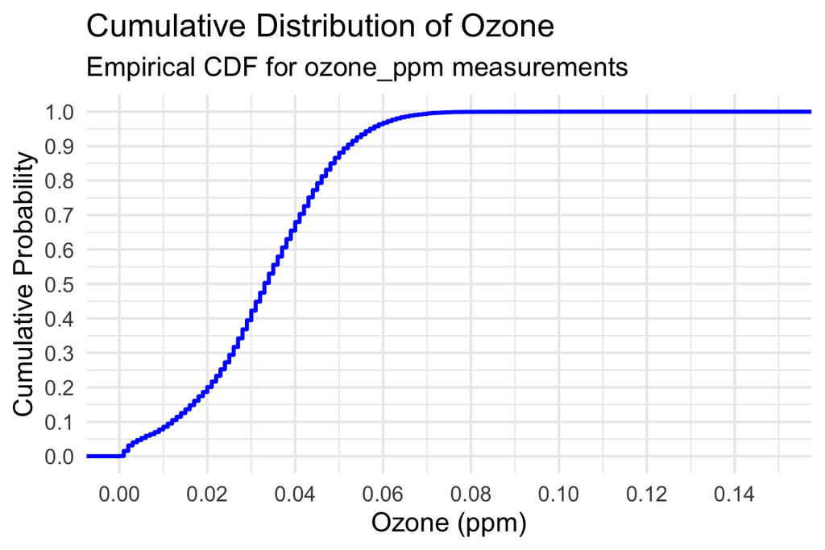

## Question 4: Histogram

Create a histogram of `ozone_ppm`. Within the `geom`, mess with the number of bins (e.g., 20, 50, 75, 100, 200) to explore the true shape and granularity of the data. Match the plot style (e.g., title, subtitle, axis labels, theme) you chose in Question 3, with the relevant adjustments such as “Histogram” instead of “Cumulative Distribution Plot”.

[figure not shown]

### Question 5: Concept

What mathematical concept is a histogram (Q4) attempting to visualize?

Answer: A histogram is a graphical tool used to visualize the frequency distribution of a dataset. It divides the data into intervals, or bins, and shows how often values fall within each range. In effect, it approximates the probability density function of a continuous variable and allows us to understand the shape, central tendency, spread, and variability of the data.

### Question 6: Distribution

Based on the histogram (Q4), does ozone concentration appear to be normally distributed?

### Question 7: Outliers

Based on the histogram (Q4), do you see any possible outliers? Skewness? How might this affect the spread and central tendency?

Answer: The histogram also suggests the presence of possible outliers, particularly in the higher range of ozone concentrations. This skewness and the presence of extreme values can influence measures of central tendency and spread. Specifically, the mean is likely pulled toward the larger values, making it higher than the median, whereas the median provides a more robust measure of central tendency. Similarly, measures like the interquartile range are better suited for describing the spread of skewed data, as they are less affected by outliers.

## Question 8: Boxplot

Generate a boxplot of ozone concentration on the y-axis with a title, subtitle, y-axis label, and theme consistent with the style of the previous two plots. Use quotes (`""`) as the `x` arguments within the calls to the aesthetic and labels to remove the x-axis scale and label.

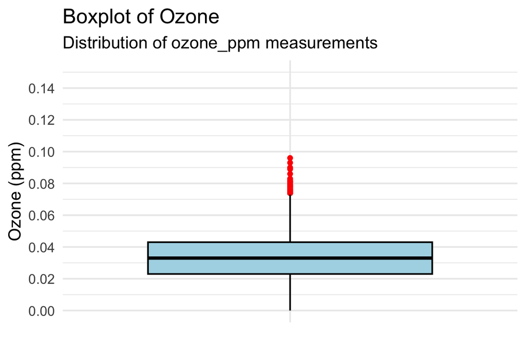

# Subset Data

Use the following code to create a dataframe for use in the remaining questions. These ozone concentration measurements were taken on July 4, 2019 in Fort Collins, CO. This code detects certain characters with the `datetime` object and filters to observations containing those characters. There are other ways this could have been done (e.g., `dplyr::filter()` with `%in%` operator).

## Question 9: Autocorrelation Plot

Define autocorrelation as it relates to ozone concentration measurement.

Definiton: Autocorrelation measures the correlation of a variable with itself at different time lags. In the context of ozone concentration measurements, it indicates whether ozone levels at one time point are related to levels at earlier (or later) time points. Positive autocorrelation means high values tend to follow high values and low values follow low values, while negative autocorrelation means high values tend to follow low values. Detecting autocorrelation helps identify temporal patterns, persistence, or periodicity in ozone measurements.

Create an autocorrelation plot of ozone concentration, using `stats::acf()` and include axis labels and title. Describe what you see based on the features of interest outlined in the coursebook.

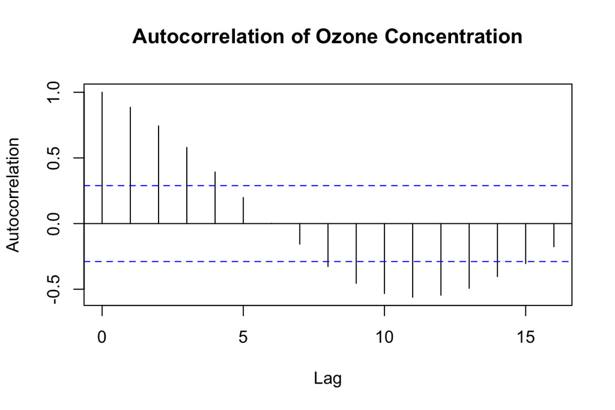

## Question 10: Parial Autocorrelation Plot

Define partial autocorrelation as it relates to ozone concentration measurement.

Now create a partial autocorrelation plot of day ozone concentration with axis labels. Describe what you see. How does this compare to the autocorrelation plot in the previous question?

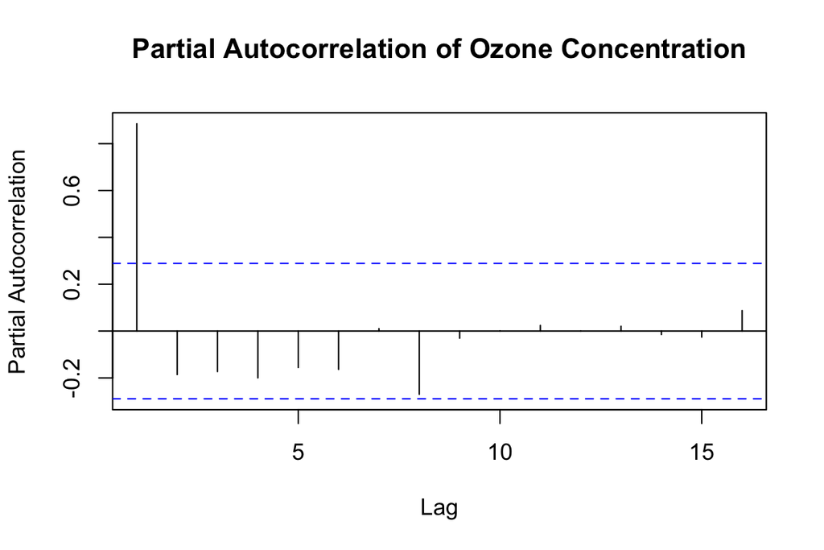

# Appendix

```r
# set global options for figures, code, warnings, and messages
knitr::opts_chunk$set(fig.width = 6, fig.height = 4, fig.path = "../figs/",
                      echo = FALSE, warning = FALSE, message = FALSE)
# load packages
library(tidyverse)
library(ggplot2)
library(dplyr)
# ozone: import, select, drop missing observations, rename
ftc <- read_csv("ftc_o3.csv")
ftc <- ftc %>%
  select(site_number, latitude, longitude,
  date_local, time_local, datetime, sample_measurement, units_of_measure,
  sample_duration, method)

ftc <- ftc %>%
  mutate(datetime = ymd_hms(datetime),
  ozone_ppm = sample_measurement)
ftc_clean <- ftc %>% filter(!is.na(ozone_ppm))

MW <- 47.998 # g/mol
T_c <- 10 # Celsius
temp_K <- 273.15 + T_c
P <- 637 # mmHg
R <- 22.4136 # (L*atm)/(mol*K)
ftc_clean <- ftc_clean %>%
  mutate(ozone_ugm3 = 1000 * ((ozone_ppm * MW * temp_K * P) / (R * (temp_K) *   P)))
ftc_clean %>% select(datetime, ozone_ppm, ozone_ppm, ozone_ugm3)
# examine dataframe object
summary(ftc_clean)

ftc_clean %>%
  summarise(
    min_value = min(.data$ozone_ppm, na.rm = TRUE),
    q1 = quantile(.data$ozone_ppm, 0.25, na.rm = TRUE),
    median_value = median(.data$ozone_ppm, na.rm = TRUE),
    q3 = quantile(.data$ozone_ppm, 0.75, na.rm = TRUE),
    max_value = max(.data$ozone_ppm, na.rm = TRUE)
  )

ftc
# plot cumulative distribution of ozone concentration
ggplot(ftc_clean, aes(x = ozone_ppm)) +
  stat_ecdf(geom = "step", color = "blue", linewidth = 1) +  # use linewidth instead of size
  scale_x_continuous(
    name = "Ozone (ppm)",
    breaks = seq(0, 0.15, by = 0.02),
    minor_breaks = seq(0, 0.15, by = 0.01),
    limits = c(0, 0.15)
  ) +
  scale_y_continuous(
    name = "Cumulative Probability",
    breaks = seq(0, 1, by = 0.1),
    minor_breaks = seq(0, 1, by = 0.05),
    limits = c(0, 1)
  ) +
  labs(
    title = "Cumulative Distribution of Ozone",
    subtitle = "Empirical CDF for ozone_ppm measurements"
  ) +
  theme_minimal(base_size = 14)
# create histogram of ozone concentration
ggplot(ftc_clean, aes(x = ozone_ppm)) +
  geom_histogram(bins = 50, fill = "skyblue", color = "black") +
  scale_x_continuous(
    name = "Ozone (ppm)",
    breaks = seq(0, 0.15, by = 0.02),
    minor_breaks = seq(0, 0.15, by = 0.01),
    limits = c(0, 0.15)
  ) +
  scale_y_continuous(
    name = "Frequency",
    breaks = seq(0, 25, by = 5),         # adjust based on your data
    minor_breaks = seq(0, 25, by = 1)
  ) +
  labs(
    title = "Histogram of Ozone",
    subtitle = "Distribution of ozone_ppm measurements"
  ) +
  theme_minimal(base_size = 14)
# create ozone boxplot
ggplot(ftc_clean, aes(x = "", y = ozone_ppm)) +  # empty x-axis
  geom_boxplot(fill = "lightblue", color = "black", outlier.color = "red", outlier.shape = 16) +
  scale_y_continuous(
    name = "Ozone (ppm)",
    breaks = seq(0, 0.15, by = 0.02),
    minor_breaks = seq(0, 0.15, by = 0.01),
    limits = c(0, 0.15)
  ) +
  labs(
    title = "Boxplot of Ozone",
    subtitle = "Distribution of ozone_ppm measurements",
    x = ""  # remove x-axis label
  ) +
  theme_minimal(base_size = 14) +
  theme(
    axis.text.x = element_blank(),  # remove x-axis text
    axis.ticks.x = element_blank()  # remove x-axis ticks
  )
# create subset of data with only one day to examine daily pattern
# I did not ask you to code this because we have not discussed dates or stringr
# You need to uncomment the below three lines and run it; check object names
ozone_day <- ftc_clean %>%
   dplyr::filter(stringr::str_detect(string = datetime,
                                     pattern = "2019-07-04"))
# create autocorrelation plot with ozone_day df
acf(ozone_day$ozone_ppm,
    main = "Autocorrelation of Ozone Concentration",
    xlab = "Lag",
    ylab = "Autocorrelation",
    na.action = na.pass)
# create partial autocorrelation plot
pacf(ozone_day$ozone_ppm,
     main = "Partial Autocorrelation of Ozone Concentration",
     xlab = "Lag",
     ylab = "Partial Autocorrelation",
     na.action = na.pass)
```